# Lesson 12 - Stijn Beernink & Bart Middelburg - Team BS - GeoScripting

## Date: 24-01-2017

Loading the needed modules

```python
from osgeo import gdal
from osgeo.gdalconst import GA_ReadOnly, GDT_Float32
import numpy as np
import os
import urllib2
import tarfile, sys
%matplotlib inline
import matplotlib.pyplot as plt
```

Download the file from Dropbox

```python
landsat_tar = urllib2.urlopen("https://www.dropbox.com/s/zb7nrla6fqi1mq4/LC81980242014260-SC20150123044700.tar.gz?dl=1")
with open('landsat.tar.gz','wb') as output:
  output.write(landsat_tar.read())
```

Define a function to be able to untar the files (function is generic, just to show how a function works)

```python
def untar(fname):
    if (fname.endswith("tar.gz")):
        tar = tarfile.open(fname)
        tar.extractall()
        tar.close()
        print "Extracted in Current Directory"
    else:
        print "Not a tar.gz file: '%s '" % sys.argv[0]
```

Run the function to untar the file

```python
untar('landsat.tar.gz')
```

```
Extracted in Current Directory
```

Open the two bands needed to calculate the NDWI

```python
band4= gdal.Open('LC81980242014260LGN00_sr_band4.tif', GA_ReadOnly)
band5= gdal.Open('LC81980242014260LGN00_sr_band5.tif', GA_ReadOnly)
```

Read in as an array to be able to calculate the NDWI

```python
band4Arr = band4.ReadAsArray(0,0,band4.RasterXSize, band4.RasterYSize)
band5Arr = band5.ReadAsArray(0,0,band5.RasterXSize, band5.RasterYSize)
```

Set the data type to float 32, otherwise it will remain integers. Integers doesn't make any sense when calculating the NDWI.

```python
band4Arr=band4Arr.astype(np.float32)
band5Arr=band5Arr.astype(np.float32)
```

Define a function to calculate ndwi. b4 is band 4 and b5 is band 5. Mask is needed to prevent dividing by zero.

```python
def ndwi_calc(b4, b5):
    mask = np.greater(b4+b5,0)
    with np.errstate(invalid='ignore',divide='ignore'):
        ndwi = np.choose(mask,(-99,(b4-b5)/(b4+b5)))
        print "NDWI min and max values", ndwi.min(), ndwi.max()
        return ndwi
```

Run the function with the loaded bands before.

```python
ndwi = ndwi_calc(band4Arr, band5Arr)
```

```
NDWI min and max values -99.0 21.3333
```

Check the real minimum, as the array contains -99.

```python
print(ndwi[ndwi>-99].min())
```

```
-2.36481
```

Remove wrong values (only a few)

```python
ndwi[ndwi>1] = -99
```

Save the created NDWI layer as ndwi.tif. All values with -99 are set to NoData

```python
band4= gdal.Open('LC81980242014260LGN00_sr_band4.tif', GA_ReadOnly)
driver = gdal.GetDriverByName('GTiff')
outDataSet=driver.Create('ndwi.tif', band4.RasterXSize, band4.RasterYSize, 1, GDT_Float32)
outBand = outDataSet.GetRasterBand(1)
outBand.WriteArray(ndwi,0,0)
outBand.SetNoDataValue(-99)
```

```
0
```

Set NDWI to the original projection of band 4

```python
outDataSet.SetProjection(band4.GetProjection())
outDataSet.SetGeoTransform(band4.GetGeoTransform())
```

```
0
```

Finally we save the tif file.

```python
outBand.FlushCache()
outDataSet.FlushCache()
```

Reproject the NDWI.tif to lon and lat (NDWI_ll.tif).

```python
bashCommand = 'gdalwarp -t_srs "EPSG:4326" ndwi.tif ndwi_ll.tif'
os.system(bashCommand)
```

```
0
```

Open the new projected file

```python
dsll = gdal.Open("ndwi_ll.tif")
```

Open as Array

```python
ndwi = dsll.ReadAsArray(0, 0, dsll.RasterXSize, dsll.RasterYSize)
```

Finally we plot the result of the whole proces. As you can see it turned out to be visually quite correct. Water is presented quite correctly on the map

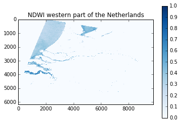

```python
plt.imshow(ndwi, interpolation='nearest', vmin=0, cmap=plt.cm.Blues)
plt.title("NDWI western part of the Netherlands")
plt.colorbar()
plt.show()

dsll = None
```

Pretty nice plot isn't it?

Greetings, Team BS